# Risk Factor Analysis

## Outcome Variable

**Outcome Variable:** pers_wast

## Predictor Variables

**Intervention Variable:** meducyrs

**Adjustment Set:**

- arm
- W_mage
- feducyrs
- W_mhtcm
- W_mwtkg
- W_mbmi
- W_gagebrth
- W_birthwt
- W_birthlen
- single
- delta_W_mage
- delta_feducyrs
- delta_W_mhtcm
- delta_W_mwtkg
- delta_W_mbmi
- delta_W_gagebrth
- delta_W_birthwt
- delta_W_birthlen
- delta_single

## Stratifying Variables

The analysis was stratified on these variable(s):

- agecat
- studyid
- country

## Data Summary

| agecat | studyid | country | meducyrs | pers_wast | n_cell | n |
| --- | --- | --- | --- | --- | --- | --- |
| 0-24 months | CMC-V-BCS-2002 | INDIA | High | 0 | 150 | 373 |
| 0-24 months | CMC-V-BCS-2002 | INDIA | High | 1 | 8 | 373 |
| 0-24 months | CMC-V-BCS-2002 | INDIA | Low | 0 | 98 | 373 |
| 0-24 months | CMC-V-BCS-2002 | INDIA | Low | 1 | 8 | 373 |
| 0-24 months | CMC-V-BCS-2002 | INDIA | Medium | 0 | 102 | 373 |
| 0-24 months | CMC-V-BCS-2002 | INDIA | Medium | 1 | 7 | 373 |
| 0-24 months | COHORTS | GUATEMALA | High | 0 | 203 | 1047 |
| 0-24 months | COHORTS | GUATEMALA | High | 1 | 6 | 1047 |
| 0-24 months | COHORTS | GUATEMALA | Low | 0 | 462 | 1047 |
| 0-24 months | COHORTS | GUATEMALA | Low | 1 | 20 | 1047 |
| 0-24 months | COHORTS | GUATEMALA | Medium | 0 | 346 | 1047 |
| 0-24 months | COHORTS | GUATEMALA | Medium | 1 | 10 | 1047 |
| 0-24 months | COHORTS | INDIA | High | 0 | 579 | 4519 |
| 0-24 months | COHORTS | INDIA | High | 1 | 31 | 4519 |
| 0-24 months | COHORTS | INDIA | Low | 0 | 1254 | 4519 |
| 0-24 months | COHORTS | INDIA | Low | 1 | 218 | 4519 |
| 0-24 months | COHORTS | INDIA | Medium | 0 | 2248 | 4519 |
| 0-24 months | COHORTS | INDIA | Medium | 1 | 189 | 4519 |
| 0-24 months | COHORTS | PHILIPPINES | High | 0 | 1013 | 2811 |
| 0-24 months | COHORTS | PHILIPPINES | High | 1 | 42 | 2811 |
| 0-24 months | COHORTS | PHILIPPINES | Low | 0 | 787 | 2811 |
| 0-24 months | COHORTS | PHILIPPINES | Low | 1 | 61 | 2811 |
| 0-24 months | COHORTS | PHILIPPINES | Medium | 0 | 867 | 2811 |
| 0-24 months | COHORTS | PHILIPPINES | Medium | 1 | 41 | 2811 |
| 0-24 months | EE | PAKISTAN | High | 0 | 15 | 374 |
| 0-24 months | EE | PAKISTAN | High | 1 | 0 | 374 |
| 0-24 months | EE | PAKISTAN | Low | 0 | 295 | 374 |
| 0-24 months | EE | PAKISTAN | Low | 1 | 31 | 374 |
| 0-24 months | EE | PAKISTAN | Medium | 0 | 31 | 374 |
| 0-24 months | EE | PAKISTAN | Medium | 1 | 2 | 374 |

[output cut: 396 more lines]

The following strata were considered:

- agecat: 0-24 months, studyid: CMC-V-BCS-2002, country: INDIA
- agecat: 0-24 months, studyid: COHORTS, country: GUATEMALA
- agecat: 0-24 months, studyid: COHORTS, country: INDIA
- agecat: 0-24 months, studyid: COHORTS, country: PHILIPPINES
- agecat: 0-24 months, studyid: EE, country: PAKISTAN
- agecat: 0-24 months, studyid: GMS-Nepal, country: NEPAL
- agecat: 0-24 months, studyid: Guatemala BSC, country: GUATEMALA
- agecat: 0-24 months, studyid: IRC, country: INDIA
- agecat: 0-24 months, studyid: JiVitA-3, country: BANGLADESH
- agecat: 0-24 months, studyid: JiVitA-4, country: BANGLADESH
- agecat: 0-24 months, studyid: LCNI-5, country: MALAWI
- agecat: 0-24 months, studyid: MAL-ED, country: BANGLADESH
- agecat: 0-24 months, studyid: MAL-ED, country: BRAZIL
- agecat: 0-24 months, studyid: MAL-ED, country: INDIA
- agecat: 0-24 months, studyid: MAL-ED, country: NEPAL
- agecat: 0-24 months, studyid: MAL-ED, country: PERU
- agecat: 0-24 months, studyid: MAL-ED, country: SOUTH AFRICA
- agecat: 0-24 months, studyid: MAL-ED, country: TANZANIA, UNITED REPUBLIC OF
- agecat: 0-24 months, studyid: NIH-Birth, country: BANGLADESH
- agecat: 0-24 months, studyid: NIH-Crypto, country: BANGLADESH
- agecat: 0-24 months, studyid: PROBIT, country: BELARUS
- agecat: 0-24 months, studyid: PROVIDE, country: BANGLADESH
- agecat: 0-24 months, studyid: SAS-CompFeed, country: INDIA
- agecat: 0-24 months, studyid: SAS-FoodSuppl, country: INDIA
- agecat: 0-24 months, studyid: TanzaniaChild2, country: TANZANIA, UNITED REPUBLIC OF
- agecat: 0-24 months, studyid: ZVITAMBO, country: ZIMBABWE
- agecat: 0-6 months, studyid: CMC-V-BCS-2002, country: INDIA
- agecat: 0-6 months, studyid: COHORTS, country: PHILIPPINES
- agecat: 0-6 months, studyid: EE, country: PAKISTAN
- agecat: 0-6 months, studyid: GMS-Nepal, country: NEPAL
- agecat: 0-6 months, studyid: IRC, country: INDIA
- agecat: 0-6 months, studyid: JiVitA-3, country: BANGLADESH
- agecat: 0-6 months, studyid: MAL-ED, country: BANGLADESH
- agecat: 0-6 months, studyid: MAL-ED, country: BRAZIL
- agecat: 0-6 months, studyid: MAL-ED, country: INDIA
- agecat: 0-6 months, studyid: MAL-ED, country: NEPAL
- agecat: 0-6 months, studyid: MAL-ED, country: PERU
- agecat: 0-6 months, studyid: MAL-ED, country: SOUTH AFRICA
- agecat: 0-6 months, studyid: MAL-ED, country: TANZANIA, UNITED REPUBLIC OF
- agecat: 0-6 months, studyid: NIH-Birth, country: BANGLADESH
- agecat: 0-6 months, studyid: NIH-Crypto, country: BANGLADESH
- agecat: 0-6 months, studyid: PROBIT, country: BELARUS
- agecat: 0-6 months, studyid: PROVIDE, country: BANGLADESH
- agecat: 0-6 months, studyid: TanzaniaChild2, country: TANZANIA, UNITED REPUBLIC OF
- agecat: 0-6 months, studyid: ZVITAMBO, country: ZIMBABWE
- agecat: 6-24 months, studyid: CMC-V-BCS-2002, country: INDIA
- agecat: 6-24 months, studyid: COHORTS, country: GUATEMALA
- agecat: 6-24 months, studyid: COHORTS, country: INDIA
- agecat: 6-24 months, studyid: COHORTS, country: PHILIPPINES
- agecat: 6-24 months, studyid: EE, country: PAKISTAN
- agecat: 6-24 months, studyid: GMS-Nepal, country: NEPAL
- agecat: 6-24 months, studyid: Guatemala BSC, country: GUATEMALA
- agecat: 6-24 months, studyid: IRC, country: INDIA
- agecat: 6-24 months, studyid: JiVitA-3, country: BANGLADESH
- agecat: 6-24 months, studyid: JiVitA-4, country: BANGLADESH
- agecat: 6-24 months, studyid: LCNI-5, country: MALAWI
- agecat: 6-24 months, studyid: MAL-ED, country: BANGLADESH
- agecat: 6-24 months, studyid: MAL-ED, country: BRAZIL
- agecat: 6-24 months, studyid: MAL-ED, country: INDIA
- agecat: 6-24 months, studyid: MAL-ED, country: NEPAL
- agecat: 6-24 months, studyid: MAL-ED, country: PERU
- agecat: 6-24 months, studyid: MAL-ED, country: SOUTH AFRICA
- agecat: 6-24 months, studyid: MAL-ED, country: TANZANIA, UNITED REPUBLIC OF
- agecat: 6-24 months, studyid: NIH-Birth, country: BANGLADESH
- agecat: 6-24 months, studyid: NIH-Crypto, country: BANGLADESH
- agecat: 6-24 months, studyid: PROBIT, country: BELARUS
- agecat: 6-24 months, studyid: PROVIDE, country: BANGLADESH
- agecat: 6-24 months, studyid: SAS-CompFeed, country: INDIA
- agecat: 6-24 months, studyid: SAS-FoodSuppl, country: INDIA
- agecat: 6-24 months, studyid: TanzaniaChild2, country: TANZANIA, UNITED REPUBLIC OF
- agecat: 6-24 months, studyid: ZVITAMBO, country: ZIMBABWE

### Dropped Strata

Some strata were dropped due to rare outcomes:

- agecat: 0-24 months, studyid: EE, country: PAKISTAN
- agecat: 0-24 months, studyid: Guatemala BSC, country: GUATEMALA
- agecat: 0-24 months, studyid: LCNI-5, country: MALAWI
- agecat: 0-24 months, studyid: MAL-ED, country: BANGLADESH
- agecat: 0-24 months, studyid: MAL-ED, country: BRAZIL
- agecat: 0-24 months, studyid: MAL-ED, country: INDIA
- agecat: 0-24 months, studyid: MAL-ED, country: NEPAL
- agecat: 0-24 months, studyid: MAL-ED, country: PERU
- agecat: 0-24 months, studyid: MAL-ED, country: SOUTH AFRICA
- agecat: 0-24 months, studyid: MAL-ED, country: TANZANIA, UNITED REPUBLIC OF
- agecat: 0-24 months, studyid: NIH-Crypto, country: BANGLADESH
- agecat: 0-24 months, studyid: PROVIDE, country: BANGLADESH
- agecat: 0-24 months, studyid: SAS-FoodSuppl, country: INDIA
- agecat: 0-24 months, studyid: TanzaniaChild2, country: TANZANIA, UNITED REPUBLIC OF
- agecat: 0-6 months, studyid: EE, country: PAKISTAN
- agecat: 0-6 months, studyid: JiVitA-3, country: BANGLADESH
- agecat: 0-6 months, studyid: MAL-ED, country: BANGLADESH
- agecat: 0-6 months, studyid: MAL-ED, country: BRAZIL
- agecat: 0-6 months, studyid: MAL-ED, country: NEPAL
- agecat: 0-6 months, studyid: MAL-ED, country: PERU
- agecat: 0-6 months, studyid: MAL-ED, country: SOUTH AFRICA
- agecat: 0-6 months, studyid: MAL-ED, country: TANZANIA, UNITED REPUBLIC OF
- agecat: 0-6 months, studyid: NIH-Birth, country: BANGLADESH
- agecat: 0-6 months, studyid: NIH-Crypto, country: BANGLADESH
- agecat: 0-6 months, studyid: PROVIDE, country: BANGLADESH
- agecat: 0-6 months, studyid: TanzaniaChild2, country: TANZANIA, UNITED REPUBLIC OF
- agecat: 0-6 months, studyid: ZVITAMBO, country: ZIMBABWE
- agecat: 6-24 months, studyid: EE, country: PAKISTAN
- agecat: 6-24 months, studyid: Guatemala BSC, country: GUATEMALA
- agecat: 6-24 months, studyid: LCNI-5, country: MALAWI
- agecat: 6-24 months, studyid: MAL-ED, country: BANGLADESH
- agecat: 6-24 months, studyid: MAL-ED, country: BRAZIL
- agecat: 6-24 months, studyid: MAL-ED, country: INDIA
- agecat: 6-24 months, studyid: MAL-ED, country: NEPAL
- agecat: 6-24 months, studyid: MAL-ED, country: PERU
- agecat: 6-24 months, studyid: MAL-ED, country: SOUTH AFRICA
- agecat: 6-24 months, studyid: MAL-ED, country: TANZANIA, UNITED REPUBLIC OF
- agecat: 6-24 months, studyid: NIH-Crypto, country: BANGLADESH
- agecat: 6-24 months, studyid: PROVIDE, country: BANGLADESH
- agecat: 6-24 months, studyid: SAS-FoodSuppl, country: INDIA
- agecat: 6-24 months, studyid: TanzaniaChild2, country: TANZANIA, UNITED REPUBLIC OF

## Methods Detail

We’re interested in the causal parameters $E[Y_a]$ for all values of $a \in \mathcal{A}$. These parameters represent the mean outcome if, possibly contrary to fact, we intervened to set all units to have $A=a$. Under the randomization and positivity assumptions, these are identified by the statistical parameters $\psi_a=E_W[E_{Y|A,W}(Y|A=a,W)]$. In addition, we’re interested in the mean of $Y$, $E[Y]$ under no intervention (the observed mean). We will estimate these parameters by using SuperLearner to fit the relevant likelihood factors – $E_{Y|A,W}(Y|A=a,W)$ and $p(A=a|W)$, and then updating our likelihood fit using a joint TMLE.

For unadjusted analyses ($W=\{\}$), initial likelihoods were estimated using Lrnr_glm to estimate the simple $E(Y|A)$ and Lrnr_mean to estimate $p(A)$. For adjusted analyses, a small library containing Lrnr_glmnet, Lrnr_xgboost, and Lrnr_mean was used.

Having estimated these parameters, we will then use the delta method to estimate relative risks and attributable risks relative to a prespecified baseline level of $A$.

# Results Detail

## Results Plots

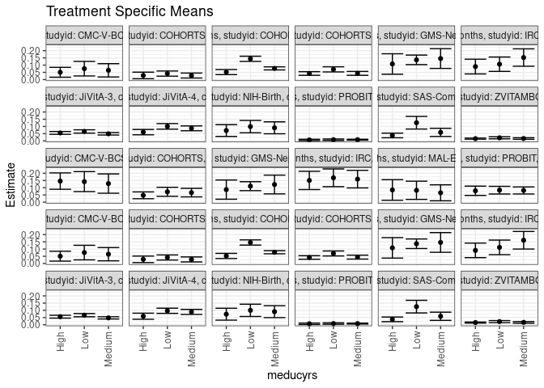

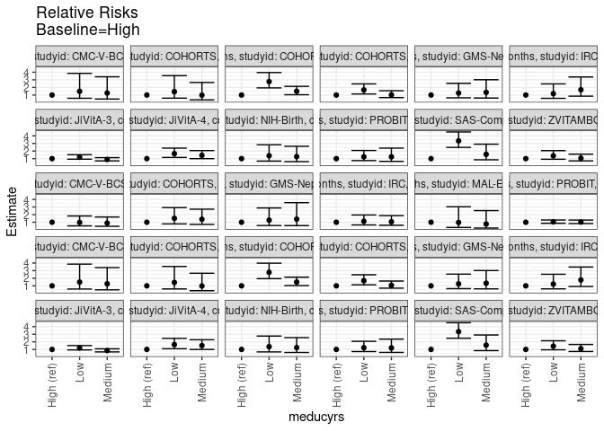

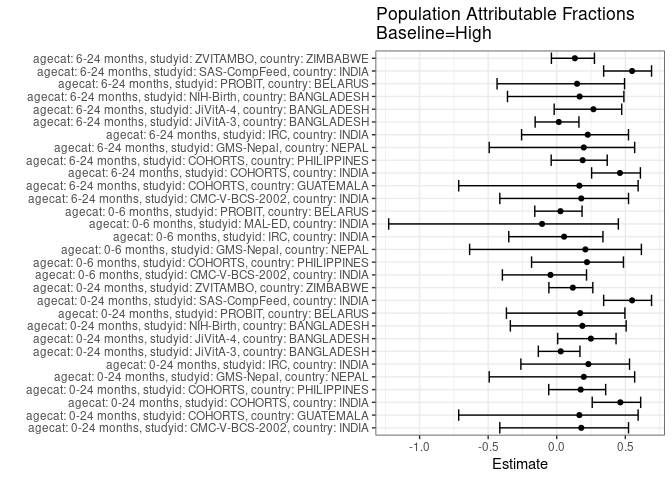

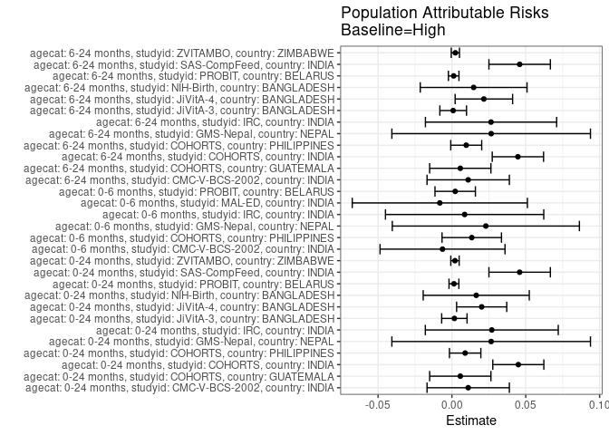

## Results Table

### Parameter: TSM

| agecat | studyid | country | intervention_level | baseline_level | estimate | ci_lower | ci_upper |
| --- | --- | --- | --- | --- | --- | --- | --- |
| 0-24 months | CMC-V-BCS-2002 | INDIA | High | NA | 0.0506329 | 0.0164006 | 0.0848652 |
| 0-24 months | CMC-V-BCS-2002 | INDIA | Low | NA | 0.0754717 | 0.0251181 | 0.1258253 |
| 0-24 months | CMC-V-BCS-2002 | INDIA | Medium | NA | 0.0642202 | 0.0181372 | 0.1103031 |
| 0-24 months | COHORTS | GUATEMALA | High | NA | 0.0287081 | 0.0060586 | 0.0513577 |
| 0-24 months | COHORTS | GUATEMALA | Low | NA | 0.0414938 | 0.0236814 | 0.0593061 |
| 0-24 months | COHORTS | GUATEMALA | Medium | NA | 0.0280899 | 0.0109180 | 0.0452618 |
| 0-24 months | COHORTS | INDIA | High | NA | 0.0519666 | 0.0344908 | 0.0694425 |
| 0-24 months | COHORTS | INDIA | Low | NA | 0.1439133 | 0.1259370 | 0.1618895 |
| 0-24 months | COHORTS | INDIA | Medium | NA | 0.0775004 | 0.0668615 | 0.0881394 |
| 0-24 months | COHORTS | PHILIPPINES | High | NA | 0.0422684 | 0.0298156 | 0.0547211 |
| 0-24 months | COHORTS | PHILIPPINES | Low | NA | 0.0708192 | 0.0531760 | 0.0884624 |
| 0-24 months | COHORTS | PHILIPPINES | Medium | NA | 0.0431586 | 0.0298069 | 0.0565103 |
| 0-24 months | GMS-Nepal | NEPAL | High | NA | 0.1081081 | 0.0372999 | 0.1789163 |
| 0-24 months | GMS-Nepal | NEPAL | Low | NA | 0.1366906 | 0.1036918 | 0.1696895 |
| 0-24 months | GMS-Nepal | NEPAL | Medium | NA | 0.1456311 | 0.0774529 | 0.2138092 |
| 0-24 months | IRC | INDIA | High | NA | 0.0900762 | 0.0391359 | 0.1410166 |
| 0-24 months | IRC | INDIA | Low | NA | 0.1065079 | 0.0567231 | 0.1562927 |
| 0-24 months | IRC | INDIA | Medium | NA | 0.1524562 | 0.0921757 | 0.2127367 |
| 0-24 months | JiVitA-3 | BANGLADESH | High | NA | 0.0551490 | 0.0455654 | 0.0647325 |
| 0-24 months | JiVitA-3 | BANGLADESH | Low | NA | 0.0652476 | 0.0537051 | 0.0767901 |
| 0-24 months | JiVitA-3 | BANGLADESH | Medium | NA | 0.0491459 | 0.0405143 | 0.0577776 |
| 0-24 months | JiVitA-4 | BANGLADESH | High | NA | 0.0606582 | 0.0420729 | 0.0792435 |
| 0-24 months | JiVitA-4 | BANGLADESH | Low | NA | 0.1004795 | 0.0811772 | 0.1197818 |
| 0-24 months | JiVitA-4 | BANGLADESH | Medium | NA | 0.0868445 | 0.0701103 | 0.1035787 |
| 0-24 months | NIH-Birth | BANGLADESH | High | NA | 0.0715472 | 0.0307048 | 0.1123896 |
| 0-24 months | NIH-Birth | BANGLADESH | Low | NA | 0.0987938 | 0.0563081 | 0.1412795 |
| 0-24 months | NIH-Birth | BANGLADESH | Medium | NA | 0.0905021 | 0.0492227 | 0.1317816 |
| 0-24 months | PROBIT | BELARUS | High | NA | 0.0066975 | 0.0020058 | 0.0113891 |
| 0-24 months | PROBIT | BELARUS | Low | NA | 0.0083159 | 0.0035171 | 0.0131146 |
| 0-24 months | PROBIT | BELARUS | Medium | NA | 0.0082735 | 0.0051481 | 0.0113989 |

[output cut: 60 more lines]

### Parameter: E(Y)

| agecat | studyid | country | intervention_level | baseline_level | estimate | ci_lower | ci_upper |
| --- | --- | --- | --- | --- | --- | --- | --- |
| 0-24 months | CMC-V-BCS-2002 | INDIA | NA | NA | 0.0616622 | 0.0372186 | 0.0861058 |
| 0-24 months | COHORTS | GUATEMALA | NA | NA | 0.0343840 | 0.0233416 | 0.0454263 |
| 0-24 months | COHORTS | INDIA | NA | NA | 0.0969241 | 0.0882972 | 0.1055510 |
| 0-24 months | COHORTS | PHILIPPINES | NA | NA | 0.0512273 | 0.0430760 | 0.0593786 |
| 0-24 months | GMS-Nepal | NEPAL | NA | NA | 0.1346801 | 0.1072037 | 0.1621566 |
| 0-24 months | IRC | INDIA | NA | NA | 0.1170732 | 0.0859146 | 0.1482317 |
| 0-24 months | JiVitA-3 | BANGLADESH | NA | NA | 0.0568153 | 0.0526983 | 0.0609323 |
| 0-24 months | JiVitA-4 | BANGLADESH | NA | NA | 0.0808042 | 0.0721841 | 0.0894244 |
| 0-24 months | NIH-Birth | BANGLADESH | NA | NA | 0.0880150 | 0.0639627 | 0.1120673 |
| 0-24 months | PROBIT | BELARUS | NA | NA | 0.0080806 | 0.0045539 | 0.0116073 |
| 0-24 months | SAS-CompFeed | INDIA | NA | NA | 0.0834553 | 0.0601989 | 0.1067118 |
| 0-24 months | ZVITAMBO | ZIMBABWE | NA | NA | 0.0176600 | 0.0150131 | 0.0203070 |
| 0-6 months | CMC-V-BCS-2002 | INDIA | NA | NA | 0.1396648 | 0.1037072 | 0.1756225 |
| 0-6 months | COHORTS | PHILIPPINES | NA | NA | 0.0609613 | 0.0448957 | 0.0770269 |
| 0-6 months | GMS-Nepal | NEPAL | NA | NA | 0.1099291 | 0.0840909 | 0.1357673 |
| 0-6 months | IRC | INDIA | NA | NA | 0.1592040 | 0.1233945 | 0.1950135 |
| 0-6 months | MAL-ED | INDIA | NA | NA | 0.0765550 | 0.0404216 | 0.1126884 |
| 0-6 months | PROBIT | BELARUS | NA | NA | 0.0810551 | 0.0555982 | 0.1065120 |
| 6-24 months | CMC-V-BCS-2002 | INDIA | NA | NA | 0.0616622 | 0.0372186 | 0.0861058 |
| 6-24 months | COHORTS | GUATEMALA | NA | NA | 0.0343840 | 0.0233416 | 0.0454263 |
| 6-24 months | COHORTS | INDIA | NA | NA | 0.0969241 | 0.0882972 | 0.1055510 |
| 6-24 months | COHORTS | PHILIPPINES | NA | NA | 0.0512273 | 0.0430760 | 0.0593786 |
| 6-24 months | GMS-Nepal | NEPAL | NA | NA | 0.1346801 | 0.1072037 | 0.1621566 |
| 6-24 months | IRC | INDIA | NA | NA | 0.1170732 | 0.0859146 | 0.1482317 |
| 6-24 months | JiVitA-3 | BANGLADESH | NA | NA | 0.0568153 | 0.0526983 | 0.0609323 |
| 6-24 months | JiVitA-4 | BANGLADESH | NA | NA | 0.0808042 | 0.0721841 | 0.0894244 |
| 6-24 months | NIH-Birth | BANGLADESH | NA | NA | 0.0880150 | 0.0639627 | 0.1120673 |
| 6-24 months | PROBIT | BELARUS | NA | NA | 0.0080806 | 0.0045539 | 0.0116073 |
| 6-24 months | SAS-CompFeed | INDIA | NA | NA | 0.0834553 | 0.0601989 | 0.1067118 |
| 6-24 months | ZVITAMBO | ZIMBABWE | NA | NA | 0.0176600 | 0.0150131 | 0.0203070 |

### Parameter: RR

| agecat | studyid | country | intervention_level | baseline_level | estimate | ci_lower | ci_upper |
| --- | --- | --- | --- | --- | --- | --- | --- |
| 0-24 months | CMC-V-BCS-2002 | INDIA | High | High | 1.0000000 | 1.0000000 | 1.000000 |
| 0-24 months | CMC-V-BCS-2002 | INDIA | Low | High | 1.4905660 | 0.5765449 | 3.853624 |
| 0-24 months | CMC-V-BCS-2002 | INDIA | Medium | High | 1.2683486 | 0.4732218 | 3.399481 |
| 0-24 months | COHORTS | GUATEMALA | High | High | 1.0000000 | 1.0000000 | 1.000000 |
| 0-24 months | COHORTS | GUATEMALA | Low | High | 1.4453665 | 0.5887096 | 3.548582 |
| 0-24 months | COHORTS | GUATEMALA | Medium | High | 0.9784644 | 0.3606476 | 2.654648 |
| 0-24 months | COHORTS | INDIA | High | High | 1.0000000 | 1.0000000 | 1.000000 |
| 0-24 months | COHORTS | INDIA | Low | High | 2.7693391 | 1.9351758 | 3.963071 |
| 0-24 months | COHORTS | INDIA | Medium | High | 1.4913498 | 1.0375442 | 2.143643 |
| 0-24 months | COHORTS | PHILIPPINES | High | High | 1.0000000 | 1.0000000 | 1.000000 |
| 0-24 months | COHORTS | PHILIPPINES | Low | High | 1.6754659 | 1.1393775 | 2.463789 |
| 0-24 months | COHORTS | PHILIPPINES | Medium | High | 1.0210616 | 0.6664046 | 1.564465 |
| 0-24 months | GMS-Nepal | NEPAL | High | High | 1.0000000 | 1.0000000 | 1.000000 |
| 0-24 months | GMS-Nepal | NEPAL | Low | High | 1.2643885 | 0.6291027 | 2.541204 |
| 0-24 months | GMS-Nepal | NEPAL | Medium | High | 1.3470874 | 0.6022147 | 3.013285 |
| 0-24 months | IRC | INDIA | High | High | 1.0000000 | 1.0000000 | 1.000000 |
| 0-24 months | IRC | INDIA | Low | High | 1.1824198 | 0.5675313 | 2.463506 |
| 0-24 months | IRC | INDIA | Medium | High | 1.6925242 | 0.8486959 | 3.375341 |
| 0-24 months | JiVitA-3 | BANGLADESH | High | High | 1.0000000 | 1.0000000 | 1.000000 |
| 0-24 months | JiVitA-3 | BANGLADESH | Low | High | 1.1831154 | 0.9252210 | 1.512895 |
| 0-24 months | JiVitA-3 | BANGLADESH | Medium | High | 0.8911487 | 0.7038401 | 1.128305 |
| 0-24 months | JiVitA-4 | BANGLADESH | High | High | 1.0000000 | 1.0000000 | 1.000000 |
| 0-24 months | JiVitA-4 | BANGLADESH | Low | High | 1.6564875 | 1.1508869 | 2.384205 |
| 0-24 months | JiVitA-4 | BANGLADESH | Medium | High | 1.4317039 | 0.9946558 | 2.060789 |
| 0-24 months | NIH-Birth | BANGLADESH | High | High | 1.0000000 | 1.0000000 | 1.000000 |
| 0-24 months | NIH-Birth | BANGLADESH | Low | High | 1.3808191 | 0.6753800 | 2.823095 |
| 0-24 months | NIH-Birth | BANGLADESH | Medium | High | 1.2649289 | 0.6090212 | 2.627240 |
| 0-24 months | PROBIT | BELARUS | High | High | 1.0000000 | 1.0000000 | 1.000000 |
| 0-24 months | PROBIT | BELARUS | Low | High | 1.2416404 | 0.7422883 | 2.076916 |
| 0-24 months | PROBIT | BELARUS | Medium | High | 1.2353166 | 0.6400826 | 2.384079 |

[output cut: 60 more lines]

### Parameter: PAR

| agecat | studyid | country | intervention_level | baseline_level | estimate | ci_lower | ci_upper |
| --- | --- | --- | --- | --- | --- | --- | --- |
| 0-24 months | CMC-V-BCS-2002 | INDIA | High | NA | 0.0110293 | -0.0168377 | 0.0388962 |
| 0-24 months | COHORTS | GUATEMALA | High | NA | 0.0056758 | -0.0150637 | 0.0264153 |
| 0-24 months | COHORTS | INDIA | High | NA | 0.0449575 | 0.0276807 | 0.0622342 |
| 0-24 months | COHORTS | PHILIPPINES | High | NA | 0.0089590 | -0.0016738 | 0.0195917 |
| 0-24 months | GMS-Nepal | NEPAL | High | NA | 0.0265720 | -0.0406554 | 0.0937994 |
| 0-24 months | IRC | INDIA | High | NA | 0.0269969 | -0.0180002 | 0.0719940 |
| 0-24 months | JiVitA-3 | BANGLADESH | High | NA | 0.0016663 | -0.0069196 | 0.0102523 |
| 0-24 months | JiVitA-4 | BANGLADESH | High | NA | 0.0201461 | 0.0031758 | 0.0371164 |
| 0-24 months | NIH-Birth | BANGLADESH | High | NA | 0.0164678 | -0.0194407 | 0.0523762 |
| 0-24 months | PROBIT | BELARUS | High | NA | 0.0013831 | -0.0019527 | 0.0047189 |
| 0-24 months | SAS-CompFeed | INDIA | High | NA | 0.0458596 | 0.0250560 | 0.0666631 |
| 0-24 months | ZVITAMBO | ZIMBABWE | High | NA | 0.0020728 | -0.0007612 | 0.0049068 |
| 0-6 months | CMC-V-BCS-2002 | INDIA | High | NA | -0.0063493 | -0.0486493 | 0.0359508 |
| 0-6 months | COHORTS | PHILIPPINES | High | NA | 0.0134393 | -0.0066787 | 0.0335574 |
| 0-6 months | GMS-Nepal | NEPAL | High | NA | 0.0229726 | -0.0403693 | 0.0863145 |
| 0-6 months | IRC | INDIA | High | NA | 0.0085998 | -0.0449827 | 0.0621824 |
| 0-6 months | MAL-ED | INDIA | High | NA | -0.0081907 | -0.0674787 | 0.0510972 |
| 0-6 months | PROBIT | BELARUS | High | NA | 0.0022202 | -0.0114611 | 0.0159016 |
| 6-24 months | CMC-V-BCS-2002 | INDIA | High | NA | 0.0110293 | -0.0168377 | 0.0388962 |
| 6-24 months | COHORTS | GUATEMALA | High | NA | 0.0056758 | -0.0150637 | 0.0264153 |
| 6-24 months | COHORTS | INDIA | High | NA | 0.0446720 | 0.0272911 | 0.0620528 |
| 6-24 months | COHORTS | PHILIPPINES | High | NA | 0.0096884 | -0.0007928 | 0.0201697 |
| 6-24 months | GMS-Nepal | NEPAL | High | NA | 0.0265720 | -0.0406554 | 0.0937994 |
| 6-24 months | IRC | INDIA | High | NA | 0.0264777 | -0.0179322 | 0.0708876 |
| 6-24 months | JiVitA-3 | BANGLADESH | High | NA | 0.0008576 | -0.0081707 | 0.0098858 |
| 6-24 months | JiVitA-4 | BANGLADESH | High | NA | 0.0216400 | 0.0021821 | 0.0410979 |
| 6-24 months | NIH-Birth | BANGLADESH | High | NA | 0.0147088 | -0.0214262 | 0.0508439 |
| 6-24 months | PROBIT | BELARUS | High | NA | 0.0011983 | -0.0023801 | 0.0047767 |
| 6-24 months | SAS-CompFeed | INDIA | High | NA | 0.0458596 | 0.0250560 | 0.0666631 |
| 6-24 months | ZVITAMBO | ZIMBABWE | High | NA | 0.0023353 | -0.0004445 | 0.0051150 |

### Parameter: PAF

| agecat | studyid | country | intervention_level | baseline_level | estimate | ci_lower | ci_upper |
| --- | --- | --- | --- | --- | --- | --- | --- |
| 0-24 months | CMC-V-BCS-2002 | INDIA | High | NA | 0.1788663 | -0.4151376 | 0.5235371 |
| 0-24 months | COHORTS | GUATEMALA | High | NA | 0.1650718 | -0.7149568 | 0.5935145 |
| 0-24 months | COHORTS | INDIA | High | NA | 0.4638418 | 0.2588115 | 0.6121559 |
| 0-24 months | COHORTS | PHILIPPINES | High | NA | 0.1748865 | -0.0584594 | 0.3567895 |
| 0-24 months | GMS-Nepal | NEPAL | High | NA | 0.1972973 | -0.4926666 | 0.5683352 |
| 0-24 months | IRC | INDIA | High | NA | 0.2305988 | -0.2615575 | 0.5307560 |
| 0-24 months | JiVitA-3 | BANGLADESH | High | NA | 0.0293288 | -0.1342490 | 0.1693160 |
| 0-24 months | JiVitA-4 | BANGLADESH | High | NA | 0.2493196 | 0.0067842 | 0.4326298 |
| 0-24 months | NIH-Birth | BANGLADESH | High | NA | 0.1871018 | -0.3382857 | 0.5062313 |
| 0-24 months | PROBIT | BELARUS | High | NA | 0.1711607 | -0.3668870 | 0.4974167 |
| 0-24 months | SAS-CompFeed | INDIA | High | NA | 0.5495101 | 0.3421911 | 0.6914892 |
| 0-24 months | ZVITAMBO | ZIMBABWE | High | NA | 0.1173742 | -0.0573036 | 0.2631933 |
| 0-6 months | CMC-V-BCS-2002 | INDIA | High | NA | -0.0454607 | -0.3963825 | 0.2172718 |
| 0-6 months | COHORTS | PHILIPPINES | High | NA | 0.2204565 | -0.1835262 | 0.4865445 |
| 0-6 months | GMS-Nepal | NEPAL | High | NA | 0.2089762 | -0.6353748 | 0.6173851 |
| 0-6 months | IRC | INDIA | High | NA | 0.0540178 | -0.3497885 | 0.3370203 |
| 0-6 months | MAL-ED | INDIA | High | NA | -0.1069915 | -1.2256042 | 0.4493944 |
| 0-6 months | PROBIT | BELARUS | High | NA | 0.0273918 | -0.1601745 | 0.1846341 |
| 6-24 months | CMC-V-BCS-2002 | INDIA | High | NA | 0.1788663 | -0.4151376 | 0.5235371 |
| 6-24 months | COHORTS | GUATEMALA | High | NA | 0.1650718 | -0.7149568 | 0.5935145 |
| 6-24 months | COHORTS | INDIA | High | NA | 0.4608965 | 0.2543642 | 0.6102218 |
| 6-24 months | COHORTS | PHILIPPINES | High | NA | 0.1891262 | -0.0405216 | 0.3680897 |
| 6-24 months | GMS-Nepal | NEPAL | High | NA | 0.1972973 | -0.4926666 | 0.5683352 |
| 6-24 months | IRC | INDIA | High | NA | 0.2261636 | -0.2563553 | 0.5233651 |
| 6-24 months | JiVitA-3 | BANGLADESH | High | NA | 0.0150937 | -0.1573503 | 0.1618437 |
| 6-24 months | JiVitA-4 | BANGLADESH | High | NA | 0.2678078 | -0.0187691 | 0.4737713 |
| 6-24 months | NIH-Birth | BANGLADESH | High | NA | 0.1671172 | -0.3592350 | 0.4896439 |
| 6-24 months | PROBIT | BELARUS | High | NA | 0.1482907 | -0.4351137 | 0.4945287 |
| 6-24 months | SAS-CompFeed | INDIA | High | NA | 0.5495101 | 0.3421911 | 0.6914892 |
| 6-24 months | ZVITAMBO | ZIMBABWE | High | NA | 0.1322339 | -0.0387282 | 0.2750576 |